**Kinematics**

|  | by Seungchul Lee iSystems Design Lab http://isystems.unist.ac.kr/ UNIST |
| --- | --- |

Table of Contents

# 1. Two Trains and Fly

- Two trains are on the same track a distance 100 mi apart heading towards one another, each at a speed of 10 mi/h.
- A fly starting out at the front of one train, flies towards the other at a speed of 20 mi/h.
- Upon reaching the other train, the fly turns around and continues towards the first train.
- How many kilometers does the fly travel before getting squashed in the collision of the two trains?

[figure not shown]

- http://mathworld.wolfram.com/TwoTrainsPuzzle.html

# 2. Kinematics

- way to describe the motion
  - translation
  - rotation (will be covered later)

# 3. Translation motion

**Position**

- The motion of an object is described by the position, $x(t)$, as a function of time $t$, measured in a given reference system.

**Velocity**

- Displacement

  The displacement $\Delta x(t_1)$ over the time interval from $t=t_1$ to $t=t_1+\Delta t$ is defined as:

$$ \Delta x(t_1) = x(t_1+\Delta t) - x(t_1)$$

- Average Velocity

  The average velocity from $\Delta x(t_1)$ over the time interval from $t=t_1$ to $t=t_1+\Delta t$ is defined as:

$$ \bar v(t_1) = \frac{x(t_1+\Delta t) - x(t_1)}{\Delta t} = \frac{\Delta x(t_1)}{\Delta t}$$

- Instantaneous Velocity

  The instantaneous velocity is defined as the time derivative of the position:

$$ v(t) = \lim_{\Delta t \to 0}\frac{x(t+\Delta t) - x(t)}{\Delta t} = \frac{d x(t)}{d t} = \dot x (t)$$

**Acceleration**

- average acceleration

  The average acceleration over a time interval $\Delta t$ from $t$ to $t + \Delta t$ is:

$$ \bar a(t) = \frac{v(t+\Delta t) - v(t)}{\Delta t} = \frac{\Delta v(t)}{\Delta t}$$

- instantaneous acceleration

  The instantaneous acceleration is defined as:

$$ a(t) = \lim_{\Delta t \to 0}\frac{v(t+\Delta t) - v(t)}{\Delta t} = \frac{d v(t)}{d t} = \frac{d}{dt}\frac{dx}{dt} = \frac{d^2x}{dt^2} = \dot v (t) = \ddot x(t)$$

## 3.1. Constant acceleration

$$ \begin{align*} & a = \text{const.} \\ & v = v_0 + at \\ & x = x_0 + v_0 t + \frac{1}{2} a t^2 \end{align*}$$

- zero acceleration

$$ \begin{align*} & a = 0 \\ & v = v_0 \\ & x = x_0 + v_0 t \end{align*}$$

- free fall

$$ \begin{align*} & a = -g \quad \left(+ \uparrow \right) \\ & v = v_0 -gt \\ & x = x_0 + v_0 t - \frac{1}{2}gt^2 \end{align*}$$

- for the motion of a falling tennis ball when there is no air resistance

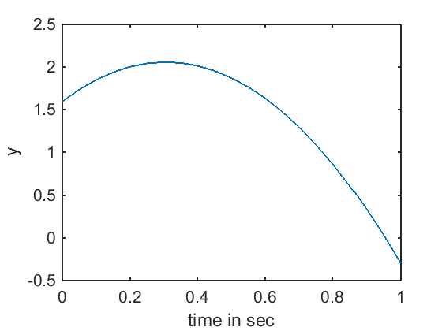

```matlab
% 1D

g = -9.8;
y0 = 1.6;
v0 = 3;
t = 0:0.05:1;
y = y0 + v0*t + 1/2*g*t.^2;

plot(t,y)
xlabel('time in sec')
ylabel('y')
```

## 3.2. Kinematics in 2-D

$$ \begin{align*} \vec{a} & = \text{const.} = a_x \hat{x} + a_y \hat{y} \\ \\ \vec{v} & = \left( v_{0x} + a_x t \right) \hat{x} + \left( v_{0y} + a_y t \right) \hat{y} \\ \\ \vec{r} & = \left( x_{0x} + v_{0x} t + \frac{1}{2} a_x t^2 \right) \hat{x} + \left( y_{0x} + v_{0y} t + \frac{1}{2} a_y t^2 \right) \hat{y} \\ \\ & \implies \; \text{Two independent 1-D motions} \end{align*}$$

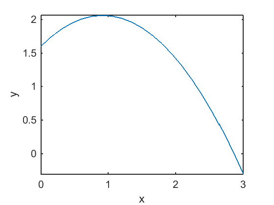

```matlab
% 2D

g = -9.8;

x0 = 0;
y0 = 1.6;

v0x = 3;
v0y = 3;

t = 0:0.05:1;
x = x0 + v0x*t;
y = y0 + v0y*t + 1/2*g*t.^2;

plot(x,y), axis equal
xlabel('x')
ylabel('y')
```

# 4. Data fitting from experimental measurements

## 4.1. Zero acceleration

- experiment video
- regression (data fitting or approximation)

```matlab
%%html
<center><iframe src="https://www.youtube.com/embed/IS3i_E9Lzw4?list=PLBD_gON7g_m33nR6eOy1GmU3b83rL1oho"
width="560" height="315" frameborder="0" allowfullscreen></iframe></center>
```

[video not shown]

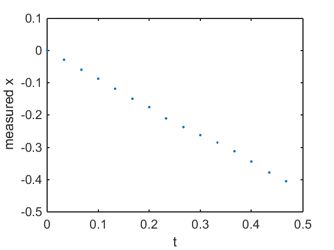

```
b =

   -0.0019
   -0.8621
```

```matlab
t = [0 0.033 0.067 0.1 0.133 0.167 0.2 0.233 0.267 0.3 0.334 0.367 0.4 0.434 0.467]';
x = [0.001 -0.028 -0.059 -0.087 -0.118 -0.149 -0.175 -0.21 -0.237 -0.262 -0.285 -0.312 -0.344 -0.378 -0.405]';

plot(t,x,'.')
xlabel('t')
ylabel('measured x')

T = [ones(size(t)) t];
b = regress(x,T)
```

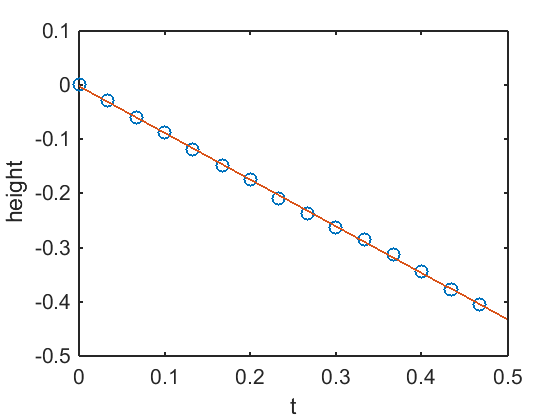

```matlab
T = [ones(size(t)) t];
b = regress(x,T);

tp = 0:0.01:0.5;
plot(t,x,'o'), hold on
plot(tp,b(1)+b(2)*tp), hold off

xlabel('t')
ylabel('height')
```

## 4.2. Constant acceleration

- experiment video
- regression (data fitting or approximation)

```matlab
%%html
<center><iframe src="https://www.youtube.com/embed/Mc6nAtbSMn0?list=PLBD_gON7g_m33nR6eOy1GmU3b83rL1oho"
width="560" height="315" frameborder="0" allowfullscreen></iframe></center>
```

[video not shown]

Experiment result

[figure not shown]

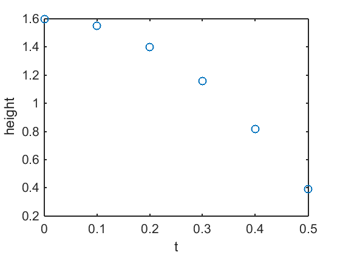

```matlab
t = 0:0.1:0.5;
t = t(:);
y = [1.6 1.55 1.4 1.16 0.82 0.39]';

plot(t,y,'o')

xlabel('t')
ylabel('height')
```

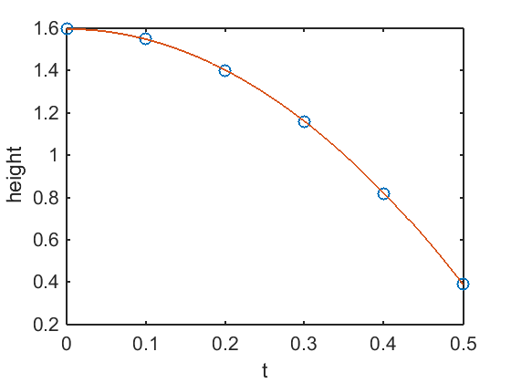

```
b =

    1.5968
   -4.8382
```

```matlab
t = 0:0.1:0.5;
t = t(:);
y = [1.6 1.55 1.4 1.16 0.82 0.39]';

T = [ones(size(t)) t.^2];
b = regress(y,T)

plot(t,y,'o'), hold on

tp = 0:0.01:0.5;
plot(tp,b(1)+b(2)*tp.^2), hold off

xlabel('t')
ylabel('height')
```

We can learn about the magnitude of the gravity

$$ 4.8383 \approx \frac{9.8}{2}$$

# 5. Data analysis from acceleration

- Usually, we do not know the position as a function of time. Instead, we want to determine the motion based on measurements of the acceleration (or velocity)
- Integral

$$ \begin{align*} v(t) &= v(t_i) + \int_{t_i}^{t} a(s)\; ds\\ x(t) &= x(t_i) + \int_{t_i}^{t} v(s)\; ds \end{align*} $$

**discrete integration (Euler's method)**

$$ \begin{align*} \upsilon(t_0) &= \upsilon_0\\ x(t_0) &= x_0\\ \\ \upsilon(t_1) &= \upsilon(t_0) + a(t_0)\Delta t\\ x(t_1) &= x(t_0) + \upsilon(t_0)\Delta t\\ \\ & \vdots\\ \\ \upsilon(t_i + \Delta t) &= \upsilon(t_i) + a(t_i)\Delta t\\ x(t_i + \Delta t) &= x(t_i) + \upsilon(t_i)\Delta t \end{align*} $$

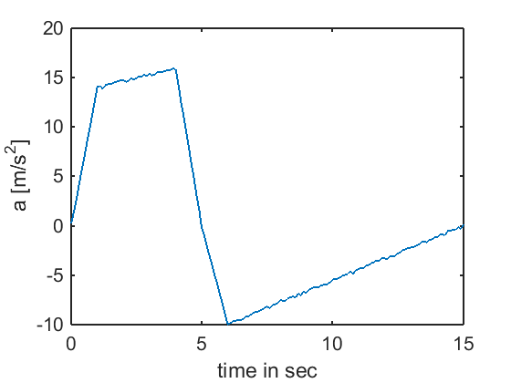

```matlab
path = [pwd, '\files'];
temp = load([path,'\therocket.dat']);

t = temp(:,1);
a = temp(:,2);

plot(t,a)
xlabel('time in sec')
ylabel('a [m/s^2]')
```

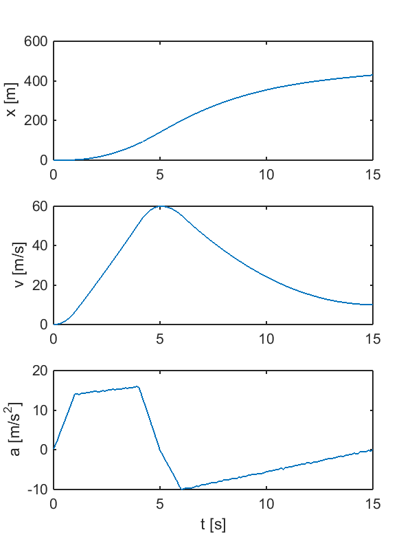

```matlab
%plot -s 600,800

t = temp(:,1);
a = temp(:,2);

dt = t(2) - t(1);

n = length(t);
v = zeros(n,1);
x = zeros(n,1);

v(1) = 0;
x(1) = 0;

for i = 1:n-1
    v(i+1) = v(i) + a(i)*dt;
    x(i+1) = x(i) + v(i)*dt;
end

subplot(3,1,1), plot(t,x), ylabel('x [m]')
subplot(3,1,2), plot(t,v), ylabel('v [m/s]')
subplot(3,1,3), plot(t,a), ylabel('a [m/s^2]'), xlabel('t [s]')
```

# 6. Data analysis from position

**Motion of a falling tennis ball**

- motion (position, or displacement) $\rightarrow$ velocity and acceleration
- derivative

$$ \begin{align*} v(t_i) &\approx \frac{r(t_{i}+\Delta t)-r(t_i)}{\Delta t}\\ a(t_i) &\approx \frac{v(t_{i}+\Delta t)-v(t_i)}{\Delta t} \end{align*} $$

```matlab
%%html
<center><iframe src="https://www.youtube.com/embed/HBsRfaix2SA"
width="560" height="315" frameborder="0" allowfullscreen></iframe></center>
```

[video not shown]

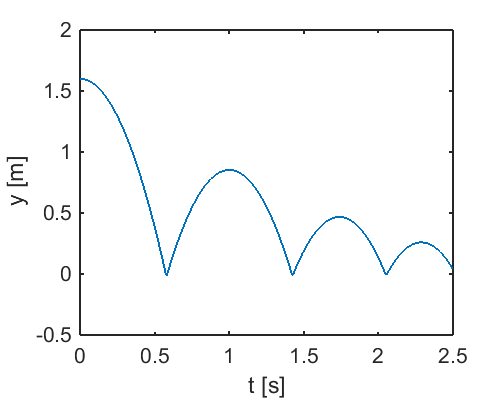

```matlab
%plot -s 500,400

path = [pwd, '\files'];
temp = load([path,'\fallingtennisball02.dat']);

t = temp(:,1);
y = temp(:,2);
plot(t,y)
xlabel('t [s]');
ylabel('y [m]');
```

$$ \begin{align*} v(t_i) &\approx \frac{r(t_{i}+\Delta t)-r(t_i)}{\Delta t}\\ a(t_i) &\approx \frac{v(t_{i}+\Delta t)-v(t_i)}{\Delta t} \end{align*} $$

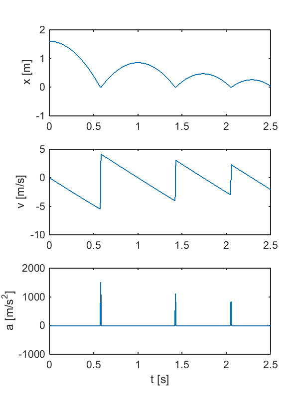

```matlab
%plot -s 600,800
n = length(t);
dt = t(2) - t(1);

v = zeros(n-1,1);
for i = 1:n-1
    v(i) = (y(i+1) - y(i))/dt;
end

a = zeros(n-2,1);
for i = 1:n-2
    a(i) = (v(i+1) - v(i))/dt;
end

subplot(3,1,1), plot(t,y), ylabel('x [m]')
subplot(3,1,2), plot(t(2:n),v), ylabel('v [m/s]')
subplot(3,1,3), plot(t(3:n),a), ylabel('a [m/s^2]'), xlabel('t [s]')
```

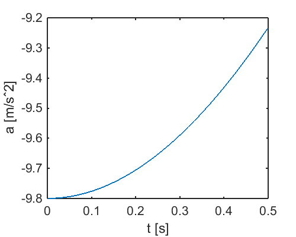

```matlab
%plot -s 500,400

imax = max(find(t<=0.5));

plot(t(3:imax),a(3:imax));
xlabel('t [s]')
ylabel('a [m/sˆ2]')
```

The acceleration is clearly not a constant in this case. It starts at $−9.8m/s^2$, but its magnitude becomes smaller with time. (This is due to air resistance).

# 7. Vector

## Vector in Coordinate

$$ \vec{A} = A_x \hat{x} + A_y \hat{y} + A_z \hat{z} = \begin{bmatrix} A_x \\ A_y \\ A_z \end{bmatrix} \quad \text{coordinate with} \; \{\hat{x}, \hat{y}, \hat{z} \}$$

for example,

- each component can be treated as a scalar

## Decomposition in 2-D

[figure not shown]

Decompose complicated motion (problem) to simple motions (subproblems)

## Projectile

[figure not shown]

$$ \begin{array}{c} \text{Given} \; \upsilon \; \text{and} \; \theta \\ H = ? \\ S = ? \end{array} \quad \quad \quad \begin{array}{c} \text{Given} \; \upsilon \\ \max\limits_{\theta}{S} \end{array}$$

```matlab
%%html
<center><iframe src="https://www.youtube.com/embed/JCampZIwL5w"
width="420" height="315" frameborder="0" allowfullscreen></iframe></center>
```

[video not shown]

## Different Frames

[figure not shown]

$$ \begin{align*} & \text{Mass} \; M \; \text{moves with velocity of} \; v_x \\ & \text{Mass} \; M \; \text{shots ball} \; m \; \text{up with velocity of} \; v_y \end{align*}$$

**For frame 1**

[figure not shown]

**For frame 2**

```matlab
%%html
<center><iframe src="https://www.youtube.com/embed/WxqrOYzTRmw"
width="420" height="315" frameborder="0" allowfullscreen></iframe></center>
```

[video not shown]

```matlab
%%html
<center><iframe src="https://www.youtube.com/embed/bZXlcDssxhY"
width="420" height="315" frameborder="0" allowfullscreen></iframe></center>
```

[video not shown]

# 8. Uniform Circular Motion

- motion of an object traveling at a constant speed on a circular path

## 8.1. Velocity

$$\text{change of vector}: \underbrace{\text{change of magnitude}}_{\text{translation}} + \underbrace{\text{change of direction}}_{\text{circular motion}}$$

[output not shown]

$$\vec{\upsilon} \text{ is tangential to the circle}$$

```matlab
%%html
<center><iframe src="https://www.youtube.com/embed/lNe59oGVLuE"
width="420" height="315" frameborder="0" allowfullscreen></iframe></center>
```

[video not shown]

```matlab
%%html
<center><iframe src="https://www.youtube.com/embed/QQKQzPJj5eg?list=PLBD_gON7g_m33nR6eOy1GmU3b83rL1oho"
width="560" height="315" frameborder="0" allowfullscreen></iframe></center>
```

[video not shown]

## 8.2. Acceleration

[output not shown]

```matlab
%%html
<center><iframe src="https://www.youtube.com/embed/kIsQlbNwtPU"
width="420" height="315" frameborder="0" allowfullscreen></iframe></center>
```

[video not shown]

## 8.3. Angular Velocity

|  | $$\begin{array}\\ & \theta &\triangleq \frac{l}{r} \text{ ( radian ) }\\ & l &= r \theta \\ & \dot l &= \dot r \theta + r \dot \theta\\ \Rightarrow & v &= r \dot \theta = r\omega \end{array}$$ |
| --- | --- |

### Angular Velocity Vector

$$\begin{array}\\ \text{line velocity } &:\vec v, \quad \text{ we know }v = r\omega\text{ (only magnitude)}\\ \text{angular velocity} &: \vec {\omega}\\ \\ \lvert \vec{\omega} \rvert = \omega\\ \vec{\omega}\text{ direction?}\\ \end{array}$$

### Cross Product

$$\vec A \times \vec B$$

[figure not shown]

$$\lvert \vec A \times \vec B \rvert = \lvert \vec A \rvert \lvert \vec B \rvert \sin \theta$$

Why do we need to know the cross product?

$$ \lvert \vec{\omega} \rvert = \omega$$

[figure not shown]

$$\vec{\omega} \text{ dirction ?}$$

### Angular Velocity and Angular Acceleration Vector

[figure not shown]

How to represent $\vec{v}$ and $\vec{a}$ in a cross product form

$$ \large \begin{array}\\ \vec{v} &= \vec{\omega} \times \vec r\\ \vec{a} &= \vec{\omega} \times \vec v\\ &= \vec{\omega} \times \left( \vec{\omega} \times \vec r\right)\\ \\ \lvert\vec{a}\rvert & = r\omega^2 = \frac{v^2}{r} \end{array} $$

```matlab
w = [0 0 1]';
r = [1 0 0]';
v = cross(w,r)
a = cross(w,v)
```

```
v =

     0
     1
     0


a =

    -1
     0
     0
```

```matlab
theta = 45*pi/180;

w = [0 0 1]';
r = [cos(theta) sin(theta) 0]';
v = cross(w,r)
a = cross(w,v)
```

```
v =

   -0.7071
    0.7071
         0


a =

   -0.7071
   -0.7071
         0
```

### Circular Motion or Spiral Motion?

$$\lvert\vec{a}\rvert > \frac{v^2}{r}\; ?$$

[figure not shown]

## 8.4. Free Fall or Circular Motion?

- what about satellites ?

# 9. General motion = translation motion + circular motion

- particle moving along the curved path

[figure not shown]

- projectile

[figure not shown]

# 10. Kinematics of Particles (or Rigid Body)

- So far, we have been considering the kinematics of a single particle
- what if a rigid body whose mass is distributed
- The Center of Mass
  - the point where all of the mass of the object is concentrated.
- treat it as a particle in the center of mass
  - the center of mass moves as if it were a point whose mass is equal to the total mass of the system
- often enable us to simplify physic problems

```matlab
%%html
<center><iframe src="https://www.youtube.com/embed/Qa_GyOv-JRE"
width="560" height="315" frameborder="0" allowfullscreen></iframe></center>
```

[video not shown]

[figure not shown]

Questions:

[figure not shown]

```matlab
%%javascript
$.getScript('https://kmahelona.github.io/ipython_notebook_goodies/ipython_notebook_toc.js')
```